# Exercise01Solution

Brian Regan

Wednesday, March 7th, 2018

## Question 1

### (b)

$Intercept \approx 680$, $Slope \approx 15$

### (d)

15 cows $\implies$ $905

100 cows $\implies$ $2180

100 is very far outside of the range of the original data and so may not be a meaningful estimate.

## Question 2

| Function | Transformation | Linear Form |
| --- | --- | --- |
| $y = \alpha x^\beta$ | $y' = log(y), x' = log(x)$ | $y' = log(\alpha) + \beta.x'$ |
| $y = \alpha e^{\beta.x}$ | $y' = log(y)$ | $y' = log(\alpha) + \beta.x$ |
| $y = \alpha + \beta.log(x)$ | $x' = log(x)$ | $y = \alpha + \beta.x'$ |
| $y = 1/(\alpha + \beta e^{-x})$ | $y' = y^{-1}, x' = e^{-x}$ | $y' = \alpha + \beta.x'$ |

## Question 3

Run 100 iterations of regression on (x, y) pairs.

```r
# Initialise Fixed X vales
iters = 100
x   <- seq(1, 40, 1)
betas <- numeric(iters)

# Conduct 100 Regressions
for(i in 1:iters){

  # Generate y's by linear function(x) + error
  y   <- 1 + 2 * x + 5 * rnorm(length(x))

  # Fit regression line
  reg <- lm(y ~ x)
  betas[i] = reg$coefficients['x']
}
```

### (a)

Plot the final regression and its Tukey-Anscombe plot.

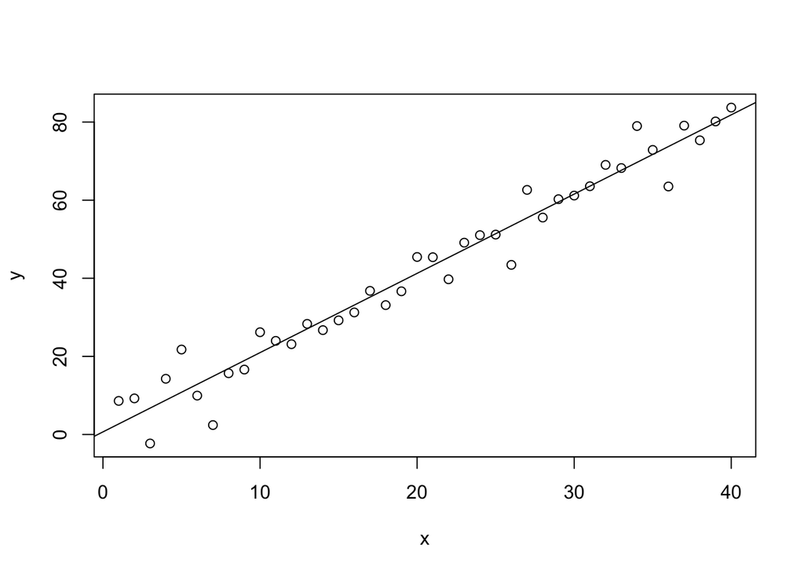

```r
plot(x, y)
abline(reg)
```

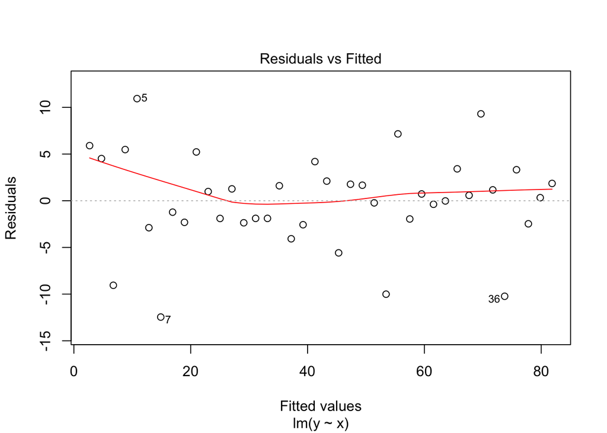

```r
plot(reg, which = 1)
```

### (b)

Compute Mean and Standard Deviation of the slopes

```r
slopeMean <- mean(betas)
slopeSD <- sd(betas)

sprintf('Mean of Slopes: %f',slopeMean)
```

```
## [1] "Mean of Slopes: 2.007539"
```

```r
sprintf('Standard Deviation of Slopes: %f', slopeSD)
```

```
## [1] "Standard Deviation of Slopes: 0.067992"
```

### (c)

```r
TheoMeanSlope = 2
TheoVarSlope= (5**2)/sum((x - mean(x))**2)
sprintf('Theoretical Variance of Slopes: %f', TheoVarSlope)
```

```
## [1] "Theoretical Variance of Slopes: 0.004690"
```

### (d)

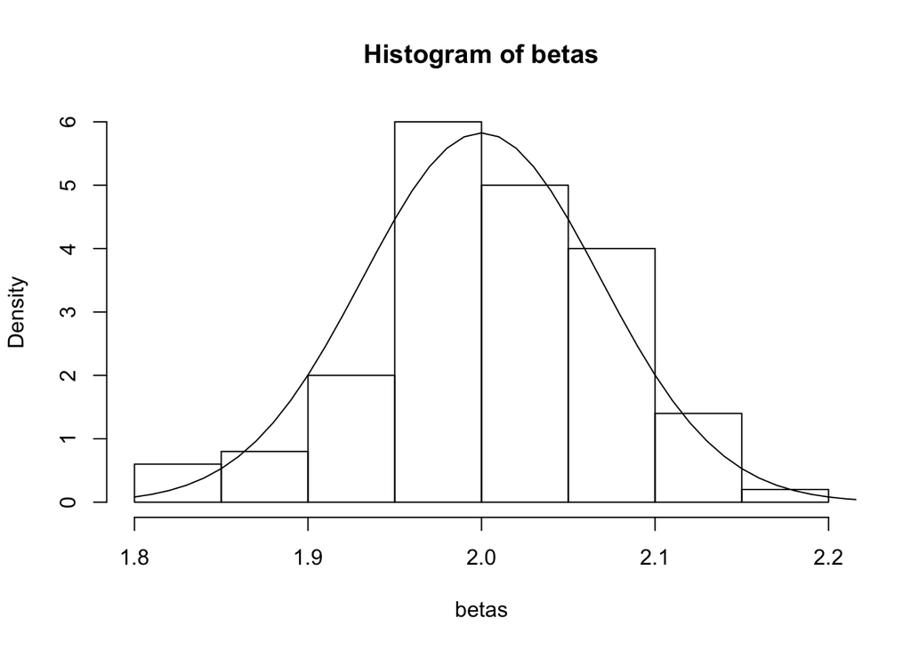

```r
hist(betas, freq = FALSE)
lines(seq(1.8, 2.3, by = 0.01), dnorm(seq(1.8, 2.3, by = 0.01), mean= TheoMeanSlope, sd = sqrt(TheoVarSlope)))
```

## Question 4

### (a)

Non-normal errors

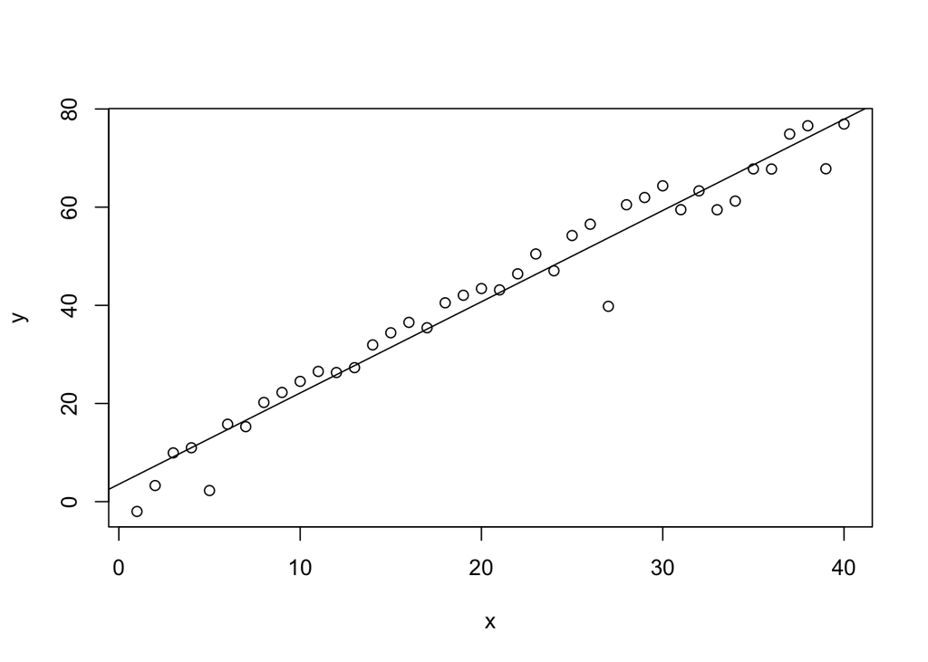

```r
# Conduct 100 Regressions
for(i in 1:iters){

  # Generate y's by linear function(x) + error
  y <- 1 + 2 * x + 5 * (1 - rchisq(length(x), df = 1)) / sqrt(2)

  # Fit regression line
  reg <- lm(y ~ x)
  betas[i] = reg$coefficients['x']
}

plot(x, y)
abline(reg)
```

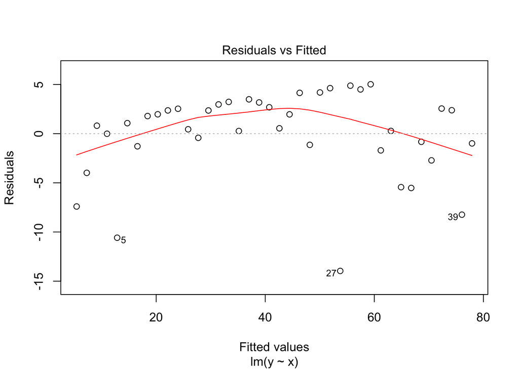

```r
plot(reg, which = 1)
```

```r
slopeMean <- mean(betas)
slopeSD <- sd(betas)

sprintf('Mean of Slopes: %f',slopeMean)
```

```
## [1] "Mean of Slopes: 1.990539"
```

```r
sprintf('Standard Deviation of Slopes: %f', slopeSD)
```

```
## [1] "Standard Deviation of Slopes: 0.079198"
```

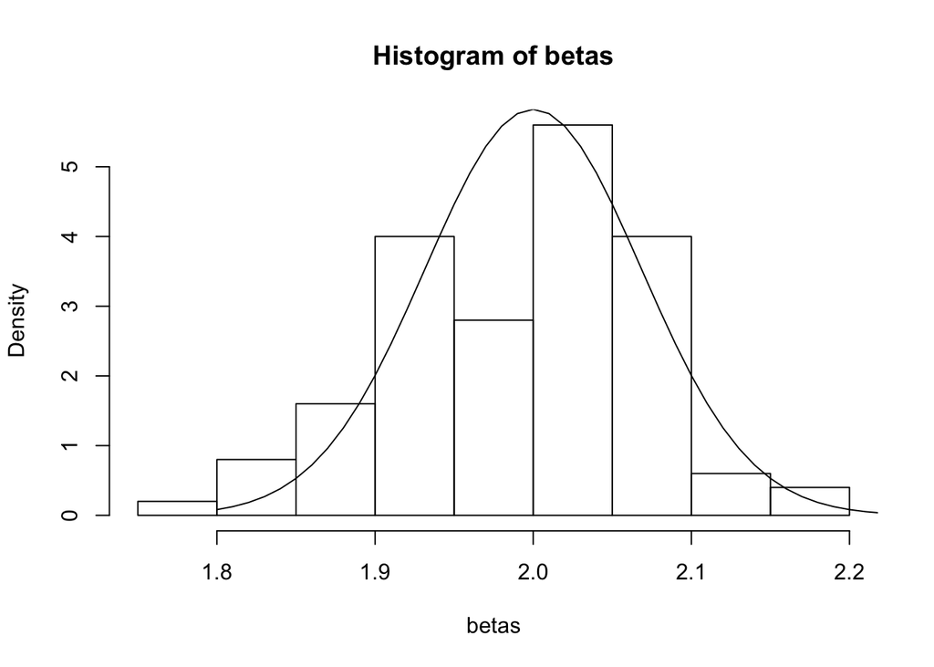

```r
hist(betas, freq = FALSE)
lines(seq(1.8, 2.3, by = 0.01), dnorm(seq(1.8, 2.3, by = 0.01), mean= TheoMeanSlope, sd = sqrt(TheoVarSlope)))
```

### (b)

Errors with non-zero mean

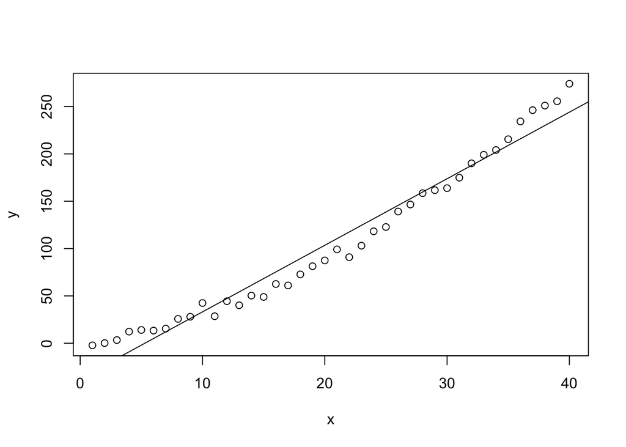

```r
# Conduct 100 Regressions
for(i in 1:iters){

  # Generate y's by linear function(x) + error
  y <- 1 + 2 * x + 5 * rnorm(length(x), mean = x^2 / 40 - 1, sd = 1)

  # Fit regression line
  reg <- lm(y ~ x)
  betas[i] = reg$coefficients['x']
}

plot(x, y)
abline(reg)
```

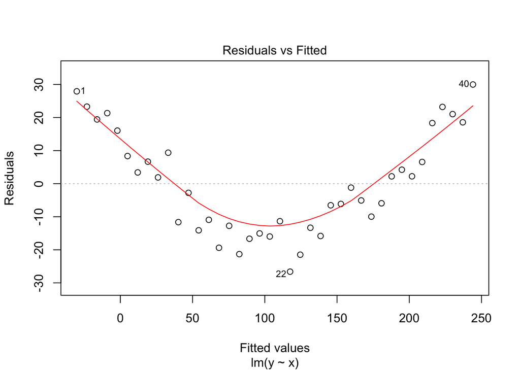

```r
plot(reg, which = 1)
```

```r
slopeMean <- mean(betas)
slopeSD <- sd(betas)

sprintf('Mean of Slopes: %f',slopeMean)
```

```
## [1] "Mean of Slopes: 7.129426"
```

```r
sprintf('Standard Deviation of Slopes: %f', slopeSD)
```

```
## [1] "Standard Deviation of Slopes: 0.063684"
```

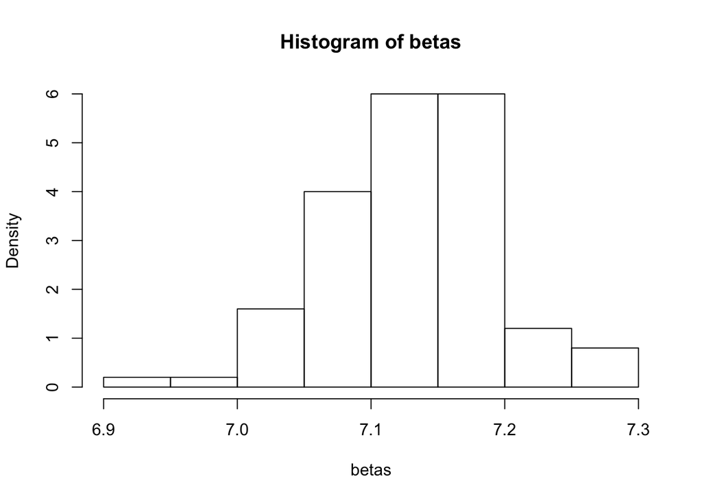

```r
hist(betas, freq = FALSE)
lines(seq(1.8, 2.3, by = 0.01), dnorm(seq(1.8, 2.3, by = 0.01), mean= TheoMeanSlope, sd = sqrt(TheoVarSlope)))
```

The expected value of the error for observation i depends on $x_i$ and so the errors are not iid. Shape, mean and variance of the distribution of $\hat{\beta}_2$ are affected.

### (c)

```r
# Conduct 100 Regressions
for(i in 1:iters){

  # Generate y's by linear function(x) + error
  require(MASS)
        Sigma <- toeplitz(c(seq(from = 1, to = 0, by = -0.1), rep(0, 29)))
        y   <- 1 + 2 * x + 5 * mvrnorm(n = 1, mu = rep(0, length(x)), Sigma = Sigma)

  # Fit regression line
  reg <- lm(y ~ x)
  betas[i] = reg$coefficients['x']
}
```

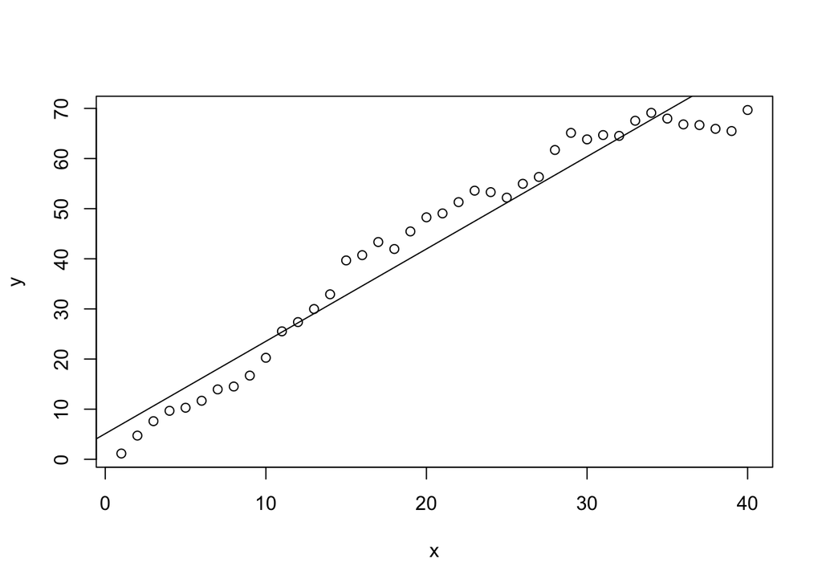

```r
plot(x, y)
abline(reg)
```

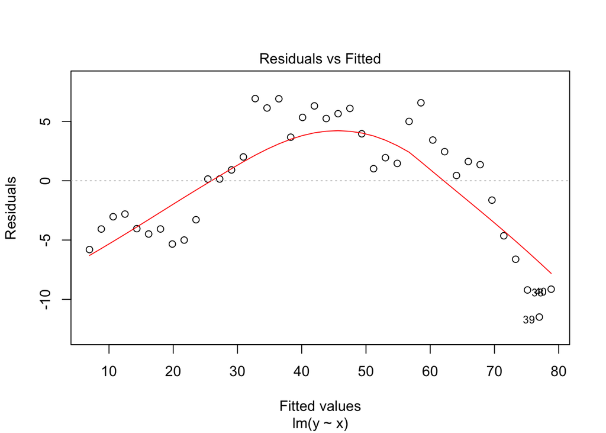

```r
plot(reg, which = 1)
```

```r
slopeMean <- mean(betas)
slopeSD <- sd(betas)

sprintf('Mean of Slopes: %f',slopeMean)
```

```
## [1] "Mean of Slopes: 2.013784"
```

```r
sprintf('Standard Deviation of Slopes: %f', slopeSD)
```

```
## [1] "Standard Deviation of Slopes: 0.187020"
```

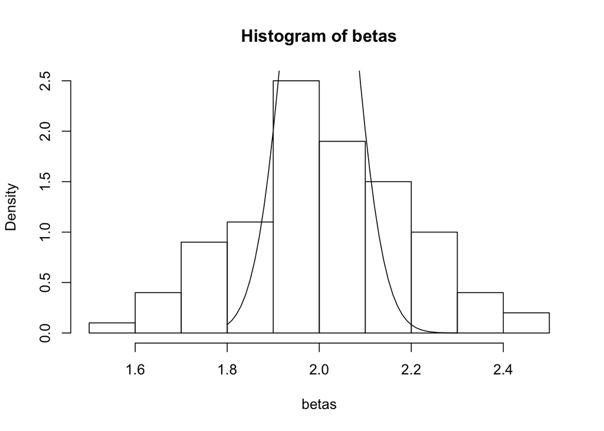

```r
hist(betas, freq = FALSE)
lines(seq(1.8, 2.3, by = 0.01), dnorm(seq(1.8, 2.3, by = 0.01), mean= TheoMeanSlope, sd = sqrt(TheoVarSlope)))
```

### (d)

Non constant (x dependent) variance of errors.

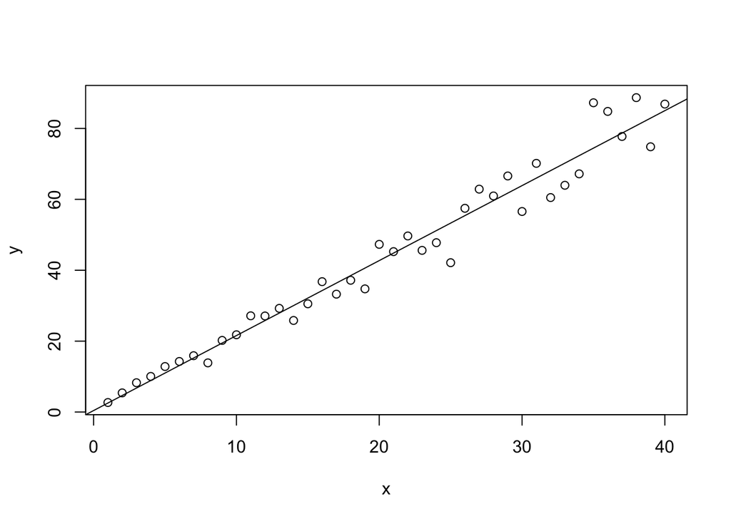

```r
# Conduct 100 Regressions
for(i in 1:iters){

  # Generate y's by linear function(x) + error
  y <- 1 + 2 * x + 5 * rnorm(length(x), mean = 0, sd = x / 20)

  # Fit regression line
  reg <- lm(y ~ x)
  betas[i] = reg$coefficients['x']
}

plot(x, y)
abline(reg)
```

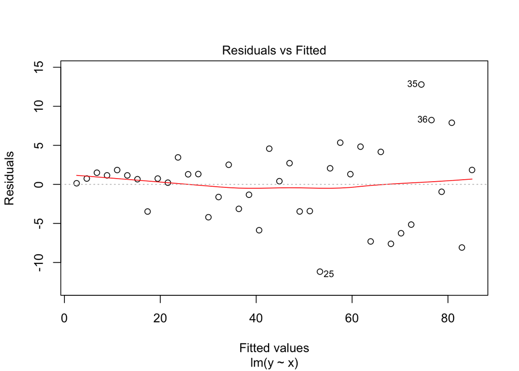

```r
plot(reg, which = 1)
```

```r
slopeMean <- mean(betas)
slopeSD <- sd(betas)

sprintf('Mean of Slopes: %f',slopeMean)
```

```
## [1] "Mean of Slopes: 2.003962"
```

```r
sprintf('Standard Deviation of Slopes: %f', slopeSD)
```

```
## [1] "Standard Deviation of Slopes: 0.082286"
```

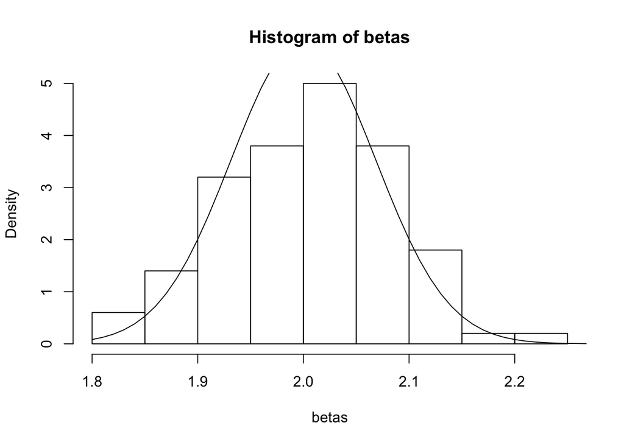

```r
hist(betas, freq = FALSE)
lines(seq(1.8, 2.3, by = 0.01), dnorm(seq(1.8, 2.3, by = 0.01), mean= TheoMeanSlope, sd = sqrt(TheoVarSlope)))
```

Here, again, we have hetroscedascity as the error $\xi_i$ depends on $x_i$ (larger error for larger x). They are still centered on zero. Mean of $\hat{\beta}_2$ distribution remains intact but not the shape and variance.